# Intro to geospatial machine learning, Part 2: Modeling the spatial structure of home prices

Ken Steif

October 4, 2019

**DRAFT - September 2019 - Please do not distrubite without the permission of the author**

## 1.1 Introduction

In the previous chapter, we discussed the three components of the hedonic home price model - internal characteristics, neighborhood amenities and the ‘underlying spatial structure’ of prices. In section x.1.5, we discussed how individual investment decisions give rise to a colletive emergence across the built environment. Some places are more dense, others, sprawling greenfield suburban development. Some neighborhoods are walkable and bustling, while others require a 10 minute drive just to get milk and eggs. As these facets of the built environment vary across space, so do the prices investors are willing to pay. The local spatial structure refers to this spatial organization.

To explain *why* prices vary across the built environment, one would have to test multiple theories related to zoning regulation; historic inequality; agglomeration economies, which give places their economic reason to be; topography; climate, and onward. However, to *predict* how prices vary across the built enviroment, the spatial process must be identified and features engineered that can account for it.

What spatial process do home prices exhibit? As the map below illustrates, prices are clearly not random. The classroom example from the introduction illustrated how certain phenomena may exhibit different spatial processes at different scales, a lesson we may be able to apply to home prices in Boston. The map below suggests that prices are systematically distributed both within certain neighobrhoods and across neighborhoods, indicating both clustering and dispersion depending on the scale.

How can we develop features that account for the underlying spatial structure of prices at so many different scales? This chapter demonstrates some of these solutions while improving on the predictive accuracy and generalizability of the model created in Chapter x. We begin by learning two methods for understanding whether the variation in price that our model could not predict (the model errors) are related across space.

Next, a new feature is engineered to help account for the across-neighborhood spatial process in home prices. This model is then compared to the “Baseline Model” created in Chapter X, asking whether these neighborhood effects help improve the accuracy and genearlizability of the model.

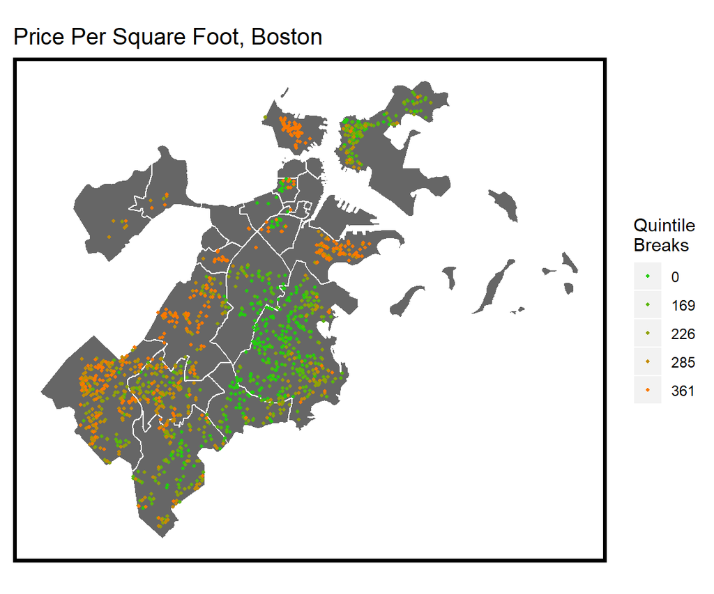

## 1.2 Setup & Data Wrangling

In this section, libraries are loaded, the final wrangled dataset created in the previous chapter is brough in, split it into training and test sets and used to re-`train` the `reg4` model. Goodness of fit metrics are then created for the `boston.test` set.

```r
library(tidyverse)
library(sf)
library(spdep)
library(caret)
library(ckanr)
library(FNN)
library(grid)
library(gridExtra)
library(knitr)
library(kableExtra)
library(tidycensus)

mapTheme <- function(base_size = 12) {
  theme(
    text = element_text( color = "black"),
    plot.title = element_text(size = 14,colour = "black"),
    plot.subtitle=element_text(face="italic"),
    plot.caption=element_text(hjust=0),
    axis.ticks = element_blank(),
    panel.background = element_blank(),axis.title = element_blank(),
    axis.text = element_blank(),
    axis.title.x = element_blank(),
    axis.title.y = element_blank(),
    panel.grid.minor = element_blank(),
    panel.border = element_rect(colour = "black", fill=NA, size=2)
  )
}

plotTheme <- function(base_size = 12) {
  theme(
    text = element_text( color = "black"),
    plot.title = element_text(size = 14,colour = "black"),
    plot.subtitle = element_text(face="italic"),
    plot.caption = element_text(hjust=0),
    axis.ticks = element_blank(),
    panel.background = element_blank(),
    panel.grid.major = element_line("grey80", size = 0.1),
    panel.grid.minor = element_blank(),
    panel.border = element_rect(colour = "black", fill=NA, size=2),
    strip.background = element_rect(fill = "grey80", color = "white"),
    strip.text = element_text(size=12),
    axis.title = element_text(size=12),
    axis.text = element_text(size=10),
    plot.background = element_blank(),
    legend.background = element_blank(),
    legend.title = element_text(colour = "black", face = "italic"),
    legend.text = element_text(colour = "black", face = "italic"),
    strip.text.x = element_text(size = 14)
  )
}


palette5 <- c("#FA7800","#C48C04","#8FA108","#5AB60C","#25CB10")
palette5 <- c("#25CB10", "#5AB60C", "#8FA108",   "#C48C04", "#FA7800")
```

Two helper functions are included, `qBr` and `q5`.

```r
#this function converts a column in to quintiles. It is used for mapping.
qBr <- function(df, variable, rnd) {
  if (missing(rnd)) {
    as.character(quantile(round(df[[variable]],0),
                          c(.01,.2,.4,.6,.8), na.rm=T))
  } else if (rnd == FALSE | rnd == F) {
    as.character(formatC(quantile(df[[variable]]), digits = 3),
                          c(.01,.2,.4,.6,.8), na.rm=T)
  }
}

q5 <- function(variable) {as.factor(ntile(variable, 5))}
```

The data is loaded.

```r
boston.sf <-  st_read("C:/Users/kennethsteif/Desktop/spring_2017/theBook/BostonHomePriceChapter_spatial/boston_sf_Ch1_wrangled.geojson") %>% st_set_crs(102286)

nhoods <-
  st_read("http://bostonopendata-boston.opendata.arcgis.com/datasets/3525b0ee6e6b427f9aab5d0a1d0a1a28_0.geojson") %>%
  st_transform(102286)
```

Here the data is split into training and test sets.

```r
inTrain <- createDataPartition(
              y = paste(boston.sf$Name, boston.sf$NUM_FLOORS.cat, boston.sf$Style, boston.sf$R_AC),
              p = .60, list = FALSE)
boston.training <- boston.sf[inTrain,]
boston.test <- boston.sf[-inTrain,]
```

Next, the model is trained and goodness of fit metrics are producted.

```r
reg4 <- lm(SalePrice ~ ., data = as.data.frame(boston.training) %>%
                                 dplyr::select(SalePrice, LivingArea, Style, GROSS_AREA, NUM_FLOORS.cat,
                                               R_BDRMS, R_FULL_BTH, R_HALF_BTH, R_KITCH, R_AC, R_FPLACE,
                                               crimes.Buffer))

boston.test <-
  boston.test %>%
  mutate(Regression = "Baseline Regression",
         SalePrice.Predict = predict(reg4, boston.test),
         SalePrice.Error = SalePrice - SalePrice.Predict,
         SalePrice.AbsError = abs(SalePrice - SalePrice.Predict),
         SalePrice.APE = (abs(SalePrice - SalePrice.Predict)) / SalePrice)%>%
  filter(SalePrice < 5000000)
```

## 2.1 Do model errors exhibit spatial autocorrelation? - The Spatial Lag

In our previous conversation on the hedonic model, we discussed the three elements that combine to predict price, internal characteristics, neighborhood amenities and the underlying spatial structure of prices. Any variation in price not accounted for by these components would fall into the error term. Assuming that our current model accounts perfectly for internal characteristics and amenties (which it doesn’t), then by this logic all of the variation related to the underlying spatial structure should fall into the error term.

We used model errors to develop a host of goodness of fit metrics in Section x.4, suggesting that one of the best ways to improve a predictive model is to try and understand model error. In this section, model errors are mapped in order to understand the extent to which the missing information in the model may be spatial in nature.

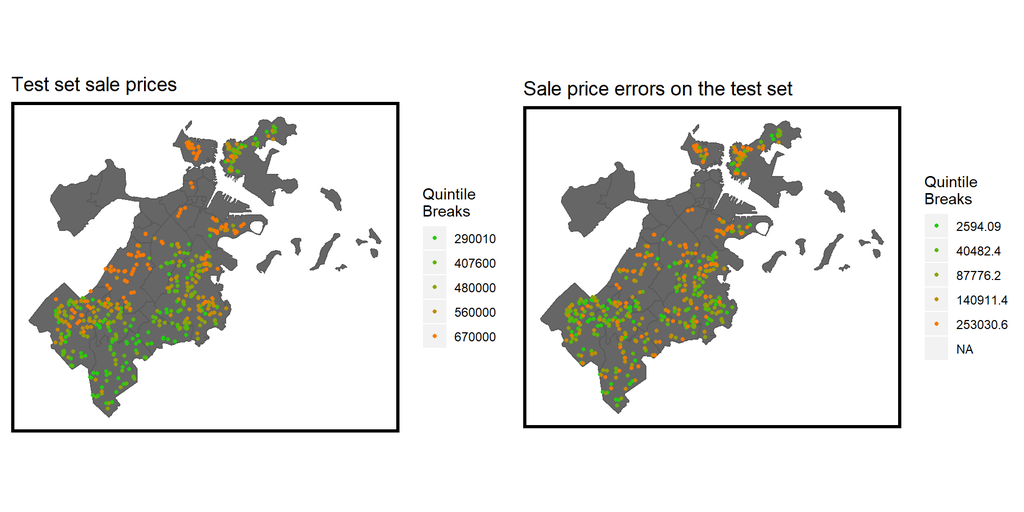

```r
grid.arrange(
  ggplot() +
    geom_sf(data = nhoods, fill = "grey40") +
    geom_sf(data = boston.test, aes(colour = q5(SalePrice)), show.legend = "point", size = 1) +
    scale_colour_manual(values = palette5,
                     labels=qBr(boston.test,"SalePrice"),
                     name="Quintile\nBreaks") +
    labs(title="Test set sale prices") +
    mapTheme(),

  ggplot() +
    geom_sf(data = nhoods, fill = "grey40") +
    geom_sf(data = boston.test, aes(colour = q5(SalePrice.AbsError)), show.legend = "point", size = 1) +
    scale_colour_manual(values = palette5,
                     labels=qBr(boston.test,"SalePrice.AbsError"),
                     name="Quintile\nBreaks") +
    labs(title="Sale price errors on the test set") +
    mapTheme(),
  ncol = 2)
```

To begin, Sale price and model errors are mapped above. Visually, it appears as though errors cluster together, but how can we test empirically whether clustering is present? Clustering is an example of spatial autocorrelation - the idea that nearer things are more related than farther things. We could pose a correlation hypothesis - stating simply, that home prices errors are correlated with nearby home prices errors. We test spatial autocorrelation using the approach below, both from home prices and model errors.

In the previous chapter, nearest neighbor approaches were used to calculate ‘exposure’ from each house to its *k* nearest crime neighbors. Below, instead of calculating average distance to nearest neighbors, each home sale observation calculates the average sale price of its *k* nearest neighbors. In spatial analysis parlance, this calculation is often referred to as the “spatial lag”, calculated below using a series of functions from the `spdep` package.

First, a data frame of coordinates, `coords`, by taking the `st_coordiantes` of `boston.sf`. The `knn2nb` function creates a `neighborList`, recoding for each point, its `5` nearest neighbors. Next, the spatial weights matrix is created which formally relates each sale price observation to those in the `neighborList`. Note that there are different approaches’ for calculating spatial weights depending on the geometry type (e.g. point vs. polygon) and the scale of interest. Here we’ve chosen 5 nearest neigbors, but there are all sorts of methods for relating one observation to its neigbors.

Finally, the `lag.listw` function calculates a spatial lag of price, `boston.sf$lagPrice`, which is the average price of a home sale’s *k = 5* nearest neighbors. Finally, `SalePrice` is plotted as a function of `lagPrice`.

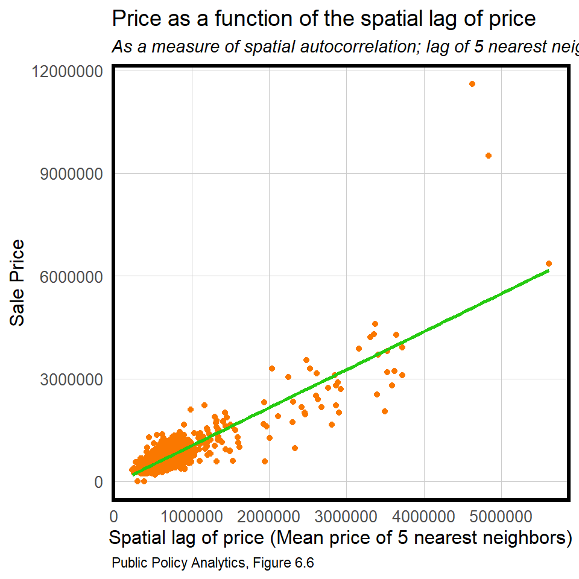

```r
coords <- st_coordinates(boston.sf)

neighborList <- knn2nb(knearneigh(coords, 5))

spatialWeights <- nb2listw(neighborList, style="W")

boston.sf$lagPrice <- lag.listw(spatialWeights, boston.sf$SalePrice)

ggplot(boston.sf, aes(lagPrice, SalePrice)) +
  geom_point(colour = "#FA7800") +
  geom_smooth(method = "lm", se = FALSE, colour = "#25CB10") +
  labs(title = "Price as a function of the spatial lag of price",
       subtitle = "As a measure of spatial autocorrelation; lag of 5 nearest neighbors",
       caption = "Public Policy Analytics, Figure 6.6",
       x = "Spatial lag of price (Mean price of 5 nearest neighbors)",
       y = "Sale Price") +
  plotTheme()
```

The correlation for this spatial lag relationship is 0.873648 and is highly statistically significant. More importantlty, the interpretation of this plot is that as price increases, the prices of nearby houses increases as well. This is substation evidence for clustering of home prices.

How about for home price model errors? The codeblock below replicate the spatial lag procedure for `SalePrice.Error`.

**This has to change. The reason the code is formated like this is because there is `NA` predictions in `boston.test`. Eventually I need to go back and solve that problem.**

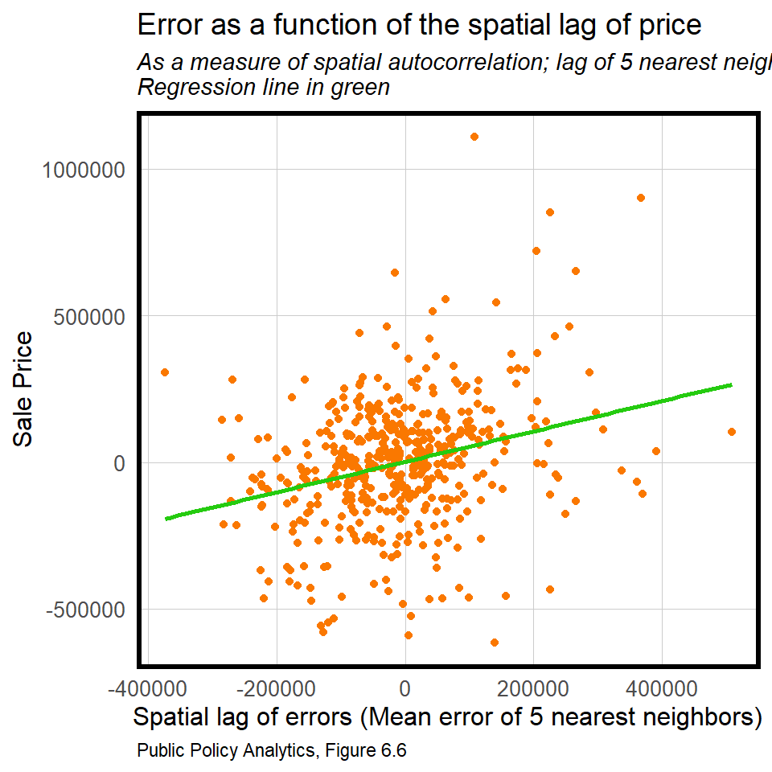

```r
coords.test <-
  filter(boston.test, !is.na(SalePrice.Error)) %>%
  st_coordinates()

neighborList.test <- knn2nb(knearneigh(coords.test, 5))

spatialWeights.test <- nb2listw(neighborList.test, style="W")

boston.test %>%
  filter(!is.na(SalePrice.Error)) %>%
  mutate(lagPriceError = lag.listw(spatialWeights.test, SalePrice.Error)) %>%
  ggplot(aes(lagPriceError, SalePrice.Error)) +
    geom_point(colour = "#FA7800") +
    geom_smooth(method = "lm", se = FALSE, colour = "#25CB10") +
    labs(title = "Error as a function of the spatial lag of price",
         subtitle = "As a measure of spatial autocorrelation; lag of 5 nearest neighbors\nRegression line in green",
         caption = "Public Policy Analytics, Figure 6.6",
         x = "Spatial lag of errors (Mean error of 5 nearest neighbors)",
         y = "Sale Price") +
    plotTheme()
```

The correlation for between house price error and nearest neighbor house price error is 0.282973 and has a p-value of 0. The interpretation is that as home price errors increase, nearby home prices errors increase as well, which is solid evidence for spatial autocorrelation in the model residuals. The important takeaway for this is that important underlying spatial variation in home prices have been omitted from our model.

Before, we learn how to develop features that can better account for this spatial autocorrelation, let’s learn a second approach for testing whether residuals exhibit spatial autocorrelation - Moran’s I.

## 2.2 Do model errors exhibit spatial autocorrelation? - Moran’s I

The Moran’s I statistic is a statistical hypothesis test that asks whether and to what extent a spatial phenomenon exhibits a given spatial process. Moran’s I analyzes neighboring values looking for instances high prices cluster near other high prices (or low prices near low prices). In practice, the test is looking to see how local means deviate from the global mean. A Moran’s I that is positive nearing the value of 1, describes positive spatial autocorrelation, also known as clustering. Instances where high and low prices “repel” one another, are said to be dispersed. The Moran’s I statistic in such an instance is closer to -1. Finally, where positive and negative values are randonly distributed, the Moran’s I statistic is 0.

Moran’s I is a null hypothesis test which holds that a spatial phenomenon is randomly distributed across space. The statistic estimates a p-value using a very intuitive process, assessing statistical significance by comapring the observed Moran’s I to a distribution of randomly permuted Moran’s I. The process works like so:

1. The point geometries of the home sale observations remain fixed in space.
2. For any given permutation, observed home prices are randomly assigned to a point.
3. Moran’s I is calculated for that permutation.
4. The process is repeated over *n* permutations creating a distribution of permuted Moran’s I values, which is then sorted.
5. If the observed Moran’s I value is greater than say, 95% of the permutated Moran’s I values, then we can conclude that the observed spatial distribution of house prices exhibits greater clustering than expected by random chance alone (a p-value of 0.05).

Figure 6.7 shows Moran’s I values for the three spatial processes. The `moran.mc` function is used to caluclate the *I* and p-value statstics. Below 999 permutations of *I* are estimated, and with the additional observed *I*, p-values are derived from 1000 total point processes. `mc` stands for ‘Monte carlo’ test and refers to the random permutation nature of the statistic. This is what is referred to as a ‘one-sided’ test, meaning that statisical significance is only attributable to clustered point processes.

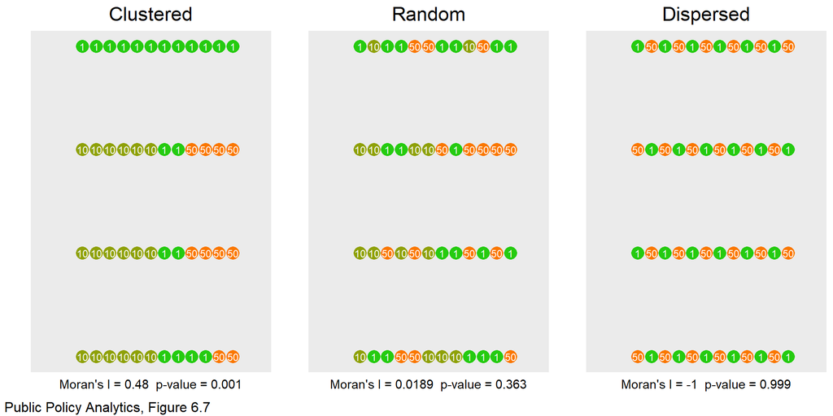

The `moran.mc` function is used below to calculate Moran’s I for the `SalePrice.Error` in `boston.test`. Note the inclusion of the `spatialWeights.test` built above. The observed Moran’s I of 0.1543909 seems marginal but the p-value of 0.001 suggests that model errors exhibit greater spatial autocorrelation than what would otherwise be expected due to random chance alone.

In Figure x.x, the frequency of all 999 randomly permutated Moran’s I are plotted as a histogram and the Observed *I* is indicated by the orange line. That the observed *I* is higher then all of the 999 randomly generated *I*’s provides visual confirmation of spatial autocorrelation. Both the spatial lag and Moran’s I test show that the residuals or errors from our predictive model exhibit spatial autocorrelation. Again, this suggests that some spatial variation related to the underlying structure of home prices has been omitted from the model. In the next section, new geospatial features are developed to help increase the accuracy and generalizability of the algorithm.

**Again, this code could be made more simple if I remove the NA from the predictions**

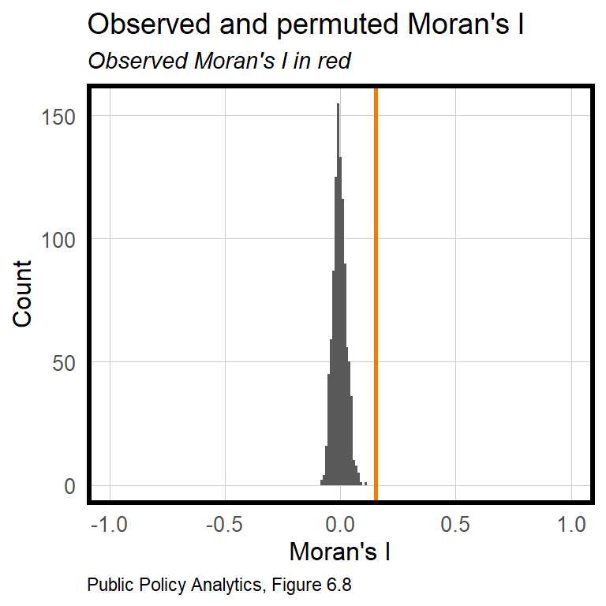

```r
moranTest <- moran.mc(filter(boston.test, !is.na(SalePrice.Error))$SalePrice.Error,
                      spatialWeights.test , nsim = 999)

ggplot(as.data.frame(moranTest$res[c(1:999)]), aes(moranTest$res[c(1:999)])) +
  geom_histogram(binwidth = 0.01) +
  geom_vline(aes(xintercept = moranTest$statistic), colour = "#FA7800",size=1) +
  scale_x_continuous(limits = c(-1, 1)) +
  labs(title="Observed and permuted Moran's I",
       subtitle= "Observed Moran's I in red",
       x="Moran's I",
       y="Count",
       caption="Public Policy Analytics, Figure 6.8") +
  plotTheme()
```

## 3.1 Account for the neighborhood fixed effect

[figure not shown]

In Section 1.1 of this chapter, I noted that both sale prices and model errors exhbit systematic spatial autocorrelation at different scales. Prices and errors cluster within many of the neighborhoods. Additionally, prices and errors seem to vary across neighborhoods. In other wrods, we might reason that there is a ‘neighborhood effect’ that can help predict variation in price. In this section, features are developed to try and account for this neighborhood effect.

The idea of a neighborhood effect should seem fairly sensible. When one buys or rents a house or apartment, one isn’t just buying a unit with 2 bedrooms, a finished kitchen, parking etc. One is buying into a neighborhood. The purpose of including neighborhood characteristics is to account for individual amenities like crime. However, it’s clear from Zillow and Craigslist listings that ‘neighborhood’ is a social and economic construct used to market real estate. Given this, let’s try to account for neighborhood variation directly in the model.

Regressing `SalePrice` as a function of neighborhood fixed effects predicts for each house in `boston.test`, the neighborhood group mean. Home prices exhibit spatial autocorrelation, and thus controlling for localized means will improve the predictive accuracy of the model. To provide a bit intution, the code block below shows that the mean `SalePrice` for each neighborhood equals the mean sale price prediction for a model trained only on the neighborhood fixed effects.

```r
left_join(
  st_set_geometry(boston.test, NULL) %>%
    group_by(Name) %>%
    summarize(meanPrice = mean(SalePrice, na.rm = T)),

  mutate(boston.test, predict.fe = predict(lm(SalePrice ~ Name, data = boston.test),
                                           boston.test)) %>%
  st_set_geometry(NULL) %>%
  group_by(Name) %>%
  summarize(meanPrediction = mean(predict.fe))) %>%
  kable() %>% kable_styling()
```

| Name | meanPrice | meanPrediction |
| --- | --- | --- |
| Beacon Hill | 2774250.0 | 2774250.0 |
| Charlestown | 972503.7 | 972503.7 |
| Dorchester | 531512.6 | 531512.6 |
| East Boston | 495314.3 | 495314.3 |
| Hyde Park | 405586.0 | 405586.0 |
| Jamaica Plain | 857088.6 | 857088.6 |
| Mattapan | 420968.4 | 420968.4 |
| Mission Hill | 1755000.0 | 1755000.0 |
| Roslindale | 509079.6 | 509079.6 |
| Roxbury | 496361.9 | 496361.9 |
| South Boston | 802704.6 | 802704.6 |
| South End | 3110000.0 | 3110000.0 |
| West Roxbury | 533803.4 | 533803.4 |

Fixed effects were discussed in x.3.4. The inclusion of these features hypothesizes statistically significant `SalePrice` differences across a set of categories. In the previous chapter, the architectural `Style` feature was demonstrated. `summary(reg4)` shows that some of `Style` fixed effects are statistically significant and make a meaningful contribution to price.

Neighborhoods can be treated as fixed effects as well. Here the hypothesis is that there is a statistically significant difference in `SalePrice` across each neighborhood in Boston. To test this hypothesis, the model is re-estimated including the `Name` feature. Note that `Name` was included in the `createDataPartition` function above to ensure that neighborhoods with few sale price observations are moved into the training set to ensure that a coefficient is estimated. The code block below estimates `reg5` and creates a data frame, `boston.test.nhood`, which includes the measures of error needed to create goodness of fit metrics.

```r
reg5 <- lm(SalePrice ~ ., data = as.data.frame(boston.training) %>%
                                 dplyr::select(Name, SalePrice, LivingArea, Style, GROSS_AREA, NUM_FLOORS.cat,
                                               R_BDRMS, R_FULL_BTH, R_HALF_BTH, R_KITCH, R_AC, R_FPLACE,
                                               crimes.Buffer))

boston.test.nhood <-
  boston.test %>%
  mutate(Regression = "Neighborhood Effects",
         SalePrice.Predict = predict(reg5, boston.test),
         SalePrice.Error = SalePrice - SalePrice.Predict,
         SalePrice.AbsError = abs(SalePrice - SalePrice.Predict),
         SalePrice.APE = (abs(SalePrice - SalePrice.Predict)) / SalePrice)%>%
  filter(SalePrice < 5000000)
```

How well does the Neighborhood Effects model improve the model relative to the Baseline Regression, `reg4`? The code block below creates error metrics from `bothRegresions`. This new data frame allows for the direct comparison of the two models.

```r
bothRegressions <-
  rbind(
    dplyr::select(boston.test, c(starts_with("SalePrice."),
                               Regression, SalePrice, Name)) %>%
      na.omit() %>%
      mutate(lagPriceError = lag.listw(spatialWeights.test, SalePrice.Error)),
    dplyr::select(boston.test.nhood, c(starts_with("SalePrice."),
                                     Regression, SalePrice, Name)) %>%
      na.omit() %>%
      mutate(lagPriceError = lag.listw(spatialWeights.test, SalePrice.Error)))
```

First, a table is created describing the Mean Absolute Error, MAE (`SalePrice.AbsError`), and Mean Absolute Percent Error, MAPE (`SalePrice.APE`), for `bothRegressions`. The Neighborhood Effects. model is far more accurate. The MAPE is almost half that of the Baseline Regression. The MAE still suggests the mean error rate is around $100k. Again, the mean `SalePrice` in `boston.test` is 598181.

```r
bothRegressions %>%
  gather(Variable, Value, -Regression, -Name, -geometry) %>%
  filter(Variable != "SalePrice" & Variable != "SalePrice.Predict") %>%
  group_by(Regression, Variable) %>%
    summarize(meanValue = mean(Value, na.rm = T)) %>%
  st_set_geometry(NULL) %>%
  spread(Variable, meanValue) %>%
  kable() %>%
    kable_styling("striped", full_width = F) %>%
    row_spec(1, color = "black", background = "#25CB10") %>%
    row_spec(2, color = "black", background = "#FA7800")
```

| Regression | lagPriceError | SalePrice.AbsError | SalePrice.APE | SalePrice.Error |
| --- | --- | --- | --- | --- |
| Baseline Regression | -11042.983 | 156000.09 | 0.2802088 | -3712.183 |
| Neighborhood Effects | 5177.189 | 94070.75 | 0.1636035 | 7290.550 |

Now on to how the distribution of predictions match the distribution of observed prices. The plot below shows that predicted and observed are far more aligned in the Neighborhood Effect model.

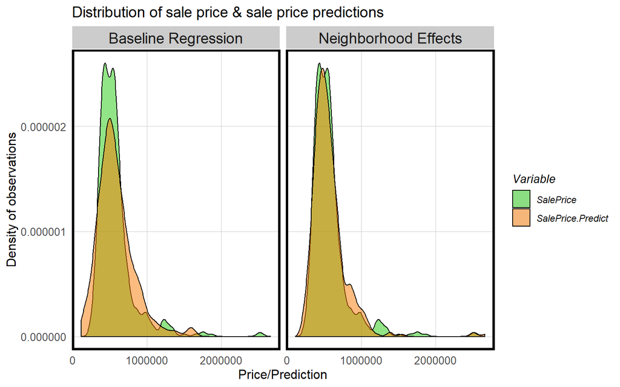

```r
bothRegressions %>%
  gather(Variable, Value, -Regression, -Name, -geometry) %>%
  filter(Variable == "SalePrice.Predict" | Variable == "SalePrice") %>%
  ggplot(aes(Value, fill = Variable)) +
    geom_density(alpha = 0.5) +
    facet_wrap(~Regression) +
    scale_fill_manual(values = c("#25CB10", "#FA7800")) +
    labs(title="Distribution of sale price & sale price predictions",
         x = "Price/Prediction", y = "Density of observations") +
    plotTheme()
```

Next, predicted prices as a function of observed prices is plotted. Recall the orange line represents a would-be perfect fit, whie the green line represents the predicted fit. The Neighborhood Effects model clearly fits the data better.

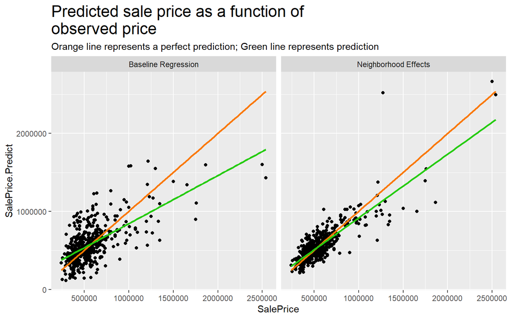

```r
bothRegressions %>%
  dplyr::select(SalePrice.Predict, SalePrice, Regression) %>%
    ggplot(aes(SalePrice, SalePrice.Predict)) +
  geom_point() +
  stat_smooth(aes(SalePrice, SalePrice),
             method = "lm", se = FALSE, size = 1, colour="#FA7800") +
  stat_smooth(aes(SalePrice, SalePrice.Predict),
              method = "lm", se = FALSE, size = 1, colour="#25CB10") +
  facet_wrap(~Regression) +
  labs(title="Predicted sale price as a function of\nobserved price",
       subtitle="Orange line represents a perfect prediction; Green line represents prediction") +
  theme(plot.title = element_text(size = 18,colour = "black"))
```

Clearly, the inclusion of neighborhood fixed effects has yielded a far more accurate model. Yet a Mean Absolute Percent Error (MAPE) of 0.1636035 is still fairly significant. In dollar terms, the Mean Absolute Error (MAE) is 94070.7543118 and the mean `SalePrice` of 598181.1707317 in the `boston.test` dataset.

Your typical regression modeler might look at the R-Squared of `reg5` at 0.9125433 and be pretty impressed by the power of their model. However, unless the model also generalizes well, the otherwise impressive R-Square may be misleading.

Nevertheless, some might expect such a high R-Square to lead to a lower MAE. What else may be omitted from this model? We’ll return to this question in the conclusion of this chapter below.

## 3.2 Spatial autocorrelation in the neighborhood model

In 2.2 we concluded that clustered model errors in space reflected the omisson of critical spatial features in our model. Given that the inclusion of neighborhood fixed effects increased the accuracy of the model by explaining of the variation in home price, we should expect model errors to be less spatially autocorrelated.

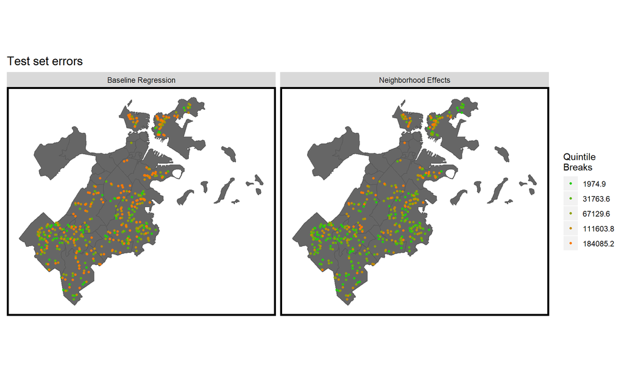

```r
bothRegressions %>%
  ggplot() +
    geom_sf(data = nhoods, fill = "grey40") +
    geom_sf(aes(colour = q5(SalePrice.AbsError)), show.legend = "point", size = 1) +
    facet_wrap(~Regression) +
    scale_colour_manual(values = palette5,
                       labels=qBr(bothRegressions,"SalePrice.AbsError"),
                       name="Quintile\nBreaks") +
    labs(title="Test set errors") +
    mapTheme()
```

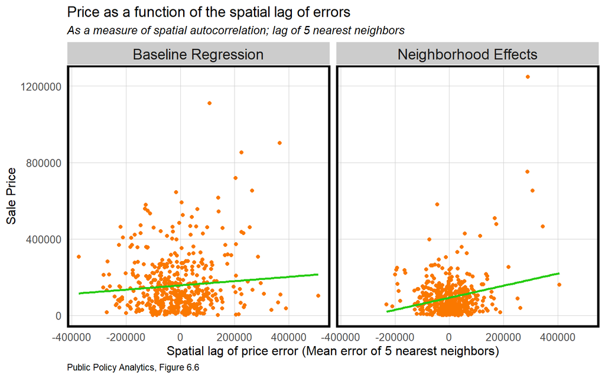

```r
bothRegressions %>%
  ggplot(aes(lagPriceError, SalePrice.AbsError)) +
    geom_point(colour = "#FA7800") +
    geom_smooth(method = "lm", se = FALSE, colour = "#25CB10") +
    facet_wrap(~Regression) +
    labs(title = "Price as a function of the spatial lag of errors",
         subtitle = "As a measure of spatial autocorrelation; lag of 5 nearest neighbors",
         caption = "Public Policy Analytics, Figure 6.6",
         x = "Spatial lag of price error (Mean error of 5 nearest neighbors)",
         y = "Sale Price") +
    plotTheme()
```

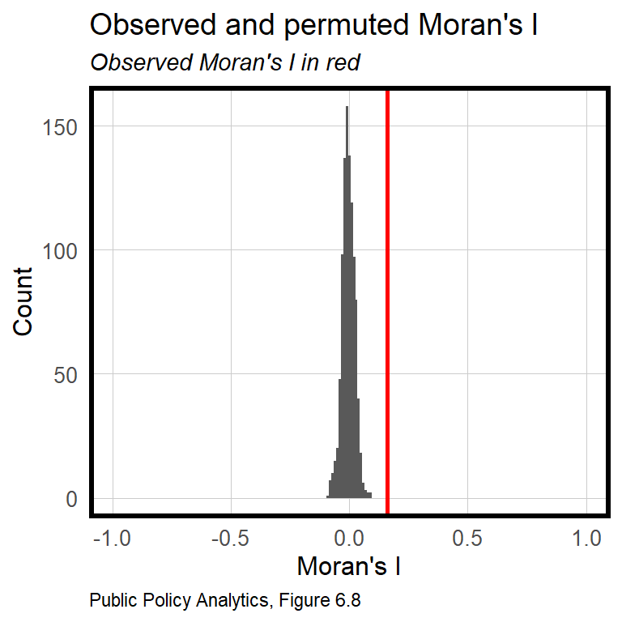

```r
moranTest.nhood <- moran.mc(filter(boston.test.nhood, !is.na(SalePrice.Error))$SalePrice.Error,
                      spatialWeights.test , nsim = 999)

ggplot(as.data.frame(moranTest.nhood$res[c(1:999)]), aes(moranTest.nhood$res[c(1:999)])) +
  geom_histogram(binwidth = 0.01) +
  geom_vline(aes(xintercept = moranTest.nhood$statistic), colour = "red",size=1) +
  scale_x_continuous(limits = c(-1, 1)) +
  labs(title="Observed and permuted Moran's I",
       subtitle= "Observed Moran's I in red",
       x="Moran's I",
       y="Count",
       caption="Public Policy Analytics, Figure 6.8") +
  plotTheme()
```

## 3.3 Generalizability of the neighborhood model

Section x.4.3 focused on cross-validation, the procedure for testing a machine learning model on many different holdouts to understand how well the model generalizes to new data. In this section, we focus on the other kind of generalizability discussed in x.1.2, ensuring a model is equally accurate across different urban contexts.

It is extremely important that our model works equally as well in rich neighborhoods as poor ones; in minority neighborhoods as white neighborhoods; in downtown neighborhoods as uptown neighborhoods. This is really chanllenging, particularly with a linear model that learns one global dynamic across all the different urban contexts in the City.

Clearly the supply and demand rules that underlie real estate markets in rich neighborhoods are different than that of poor ones. This is especially true in changing neighborhoods where some new equilibrium has yet to emerge. In effect, a model that generalizes well across different urban contexts is one that can predict for different submarkets.

In x.1.2, I gave you the example of a model trained in Phoenix and used to predict in Boston. We concluded the Boston context clearly does not generalize to Phoenix. In x.3.1, I told you that the most important nuance of the regression model is how it finds predictive signal at the mean. I mentioned the model assumes for instance, that the crime relationship to home prices is on average, similar across the City. The distribution of most urban spatial phenomena will not be similar whether its Phoenix compared to Boston or even Downtown Boston compared to West Roxbury.

The experienced modeler will correct for these differences using advanced feature engineering techniques and non-linear machine learning algorithms. In our case, let’s see how well the Baseline Regression generalizes to different urban contexts and compare that to the Neighborhood Effects regression. To do so, we begin simply by mapping mean errors by neighborhood. Then, we gather Census data to divide the City into White and minority neighborhoods, to test how well each model generalizes to both contexts.

```r
nhoods <-
  st_read("http://bostonopendata-boston.opendata.arcgis.com/datasets/3525b0ee6e6b427f9aab5d0a1d0a1a28_0.geojson") %>%
  st_set_crs(4326) %>%
  st_transform(102286)
```

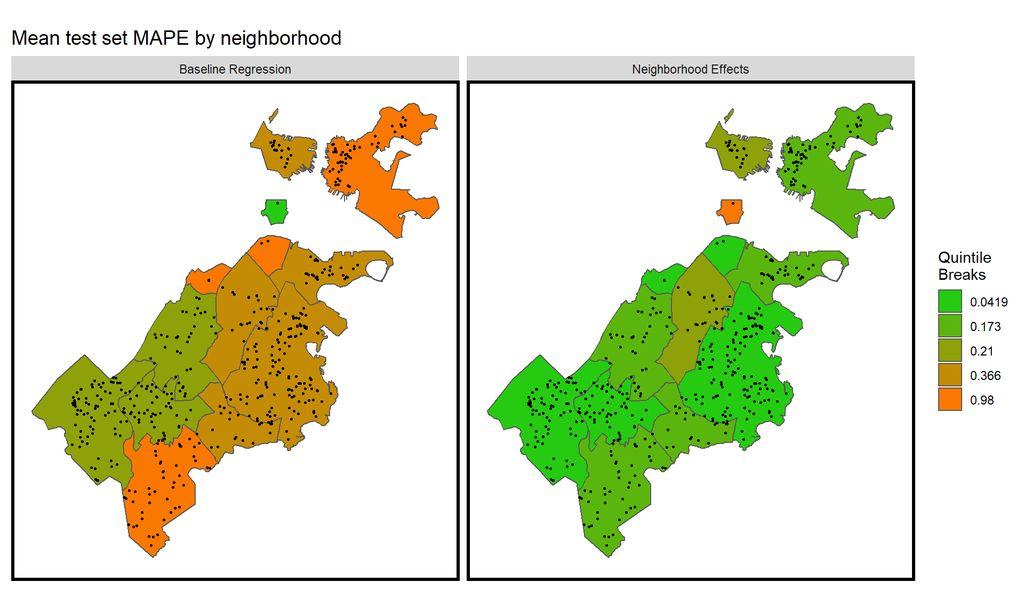

```r
bothRegressions.nhoods <-
  bothRegressions %>%
    group_by(Regression, Name) %>%
    summarize(mean.MAPE = mean(SalePrice.APE, na.rm = T)) %>%
    st_set_geometry(NULL) %>%
    left_join(nhoods) %>%
    st_sf()

 ggplot() +
  geom_sf(data = bothRegressions.nhoods, aes(fill = q5(mean.MAPE))) +
  geom_sf(data = bothRegressions, colour = "black", size = .5) +
  facet_wrap(~Regression) +
  scale_fill_manual(values = palette5,
                    labels = qBr(bothRegressions.nhoods, "mean.MAPE", rnd = F),
                    name="Quintile\nBreaks") +
  labs(title = "Mean test set MAPE by neighborhood") +
  mapTheme()
```

Next, we turn to `tidycensus` to download race data which can be use define differences in Boston’s urban context. Variables are downloaded that enable use to split Boson along both a `raceContext` and an `incomeContext`. Sales in tracts where at least 51% of residents are white receive a “Majority White” designation. Tracts with incomes greater than the citywide mean receive a “High Income” designation.

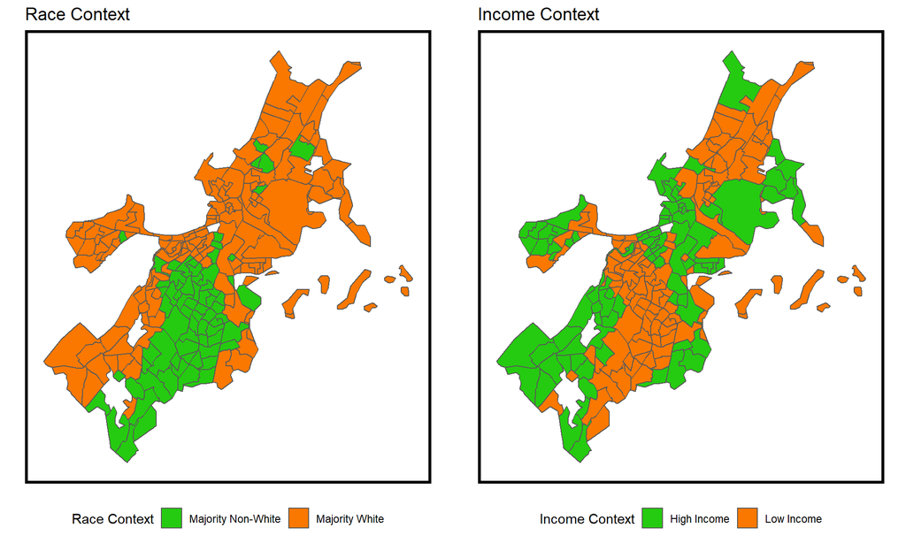

```r
tracts17 <-
get_acs(geography = "tract", variables = c("B01001_001E","B01001A_001E","B06011_001"),
        year = 2017, state=25, county=025, geometry=T) %>%
st_transform(102286)  %>%
dplyr::select(variable, estimate, GEOID) %>%
spread(variable, estimate) %>%
rename(TotalPop = B01001_001,
       NumberWhites = B01001A_001,
       Median_Income = B06011_001) %>%
mutate(percentWhite = NumberWhites / TotalPop,
       raceContext = ifelse(percentWhite > .5, "Majority White", "Majority Non-White"),
       incomeContext = ifelse(Median_Income > 32322, "High Income", "Low Income"))

grid.arrange(
  ggplot() +
    geom_sf(data = na.omit(tracts17), aes(fill = raceContext)) +
    scale_fill_manual(values = c("#25CB10", "#FA7800"),
                      name="Race Context") +
    labs(title = "Race Context") +
    mapTheme() + theme(legend.position="bottom"),

  ggplot() +
    geom_sf(data = na.omit(tracts17), aes(fill = incomeContext)) +
    scale_fill_manual(values = c("#25CB10", "#FA7800"),
                      name="Income Context") +
    labs(title = "Income Context") +
    mapTheme() + theme(legend.position="bottom"), ncol = 2)
```

Figure x.x shows that Boston is clearly segregated with respect to both race and income. In other words, the Moran’s I for each phenomena would likely be statistically significant. Given the stark contrasts across space, particularly with respect to race, we might expect it be difficult for a simple linear model to generalize well across the difference contexts.

In fact, the table below suggests otherwise. Here the mean MAPE is calculated for `bothRegressions` across both race categories. If the model generalizes well, we should expect comparable error rates for each group, which just what we see here. Clearly the Neighborhood Effects model works better than the Baseline Regression, but both seem to have similar error rates across White and non-White neighborhoods. Thus, our model generalizes well with respect to race.

```r
st_join(bothRegressions, tracts17) %>%
  group_by(Regression, raceContext) %>%
  summarize(mean.MAPE = mean(SalePrice.APE, na.rm = T)) %>%
  st_set_geometry(NULL) %>%
  spread(raceContext, mean.MAPE) %>%
  kable(caption = "Mean Absolute Error of test set sales by neighborhood racial context") %>%
    kable_styling("striped", full_width = F) %>%
    row_spec(1, color = "black", background = "#25CB10") %>%
    row_spec(2, color = "black", background = "#FA7800")
```

| Regression | Majority Non-White | Majority White |
| --- | --- | --- |
| Baseline Regression | 0.3067859 | 0.2615278 |
| Neighborhood Effects | 0.1823133 | 0.1504524 |

The story is a bit different when it comes to income however. The table below shows that there are lower error rates in High Income tracts compared to Low Income tracts. The model therefore, does not generalize as well with respect to income. What is the consequence of this? Imagine, this algorithm was going to be used to predict the market value of houses in Boston for property tax assessment purposes.

If this model was put into production - complete with higher error rates for low income communities, the City would run the risk of over-assessing low income households. This is both unfair, as we’ll discussed in Chapter x, and a political liability. The most effective solution would be to engineer features that can account for income differences across neighborhoods. A more powerful machine learning algorithm would also likely help account for these differences.

```r
st_join(bothRegressions, tracts17) %>%
  filter(!is.na(incomeContext)) %>%
  group_by(Regression, incomeContext) %>%
  summarize(mean.MAPE = mean(SalePrice.APE, na.rm = T)) %>%
  st_set_geometry(NULL) %>%
  spread(incomeContext, mean.MAPE) %>%
  kable(caption = "Mean Absolute Error of test set sales by neighborhood income context") %>%
    kable_styling("striped", full_width = F) %>%
    row_spec(1, color = "black", background = "#25CB10") %>%
    row_spec(2, color = "black", background = "#FA7800")
```

| Regression | High Income | Low Income |
| --- | --- | --- |
| Baseline Regression | 0.236482 | 0.3379626 |
| Neighborhood Effects | 0.144555 | 0.1898368 |

## 4.1 Conclusion

The previous chapter introduced both theoretical and analytical concepts critical for geospatial machine learning, culminating in the predictive model that lacked accuracy due to an inability to account for the local spatial structure of home prices. In this chapter, we learned how to evaluate prediction errors for spatial autocorelation and then considered a feature engineering approach, neighborhood fixed effects, that could account for the across-neighborhood variation in prices. The difference between a good geospatial machine learning model and a great one is often the ability to conceptualize and account for the spatial process the outcome of interest.

While neighborhood fixed effects account for the spatial structure across neighborhoods, there is another spatial structure at the within-neighborhood scale. I have purposely omitted the feature engineering to account for these dynamics because I find them to be the most challenging and creative to create. I run a home price predictive modeling competition every year for my students and the winners are always those who discover these features. While not identified directly, there are hints throughout this book about how to engineering features to account for very local spatial processes.

Some readers will be drawn to this idea of location-based fixed effects and wonder why they can’t just engineer aggregate areas that better account for within and across neighborhood price variation. Recall that fixed effects account for local sale price means. The less variance in those means, the better, and thus aggregates drawn to minimize within-neighborhood price variation are optimal. This can be a slippery slope however. The smaller the neighborhood, the more accurately one can account for local price means, but at a certain point, we might as well have a fixed effect for each house - which would of course, lead to a perfect prediction, and a very overfit model that will not generalize to new data.

This is why generalizability is such a critical component of this process. In Chapter X, cross-validation was performed on random hold-outs. As a brief aside, Figure x.x below shows that the Neighborhood Fixed Effects model is more generalizable to new data than the Baseline Regression. While generalizing to new data is critical for any machine learning algorithm, an equally important goal is to genearlize across space.

In Chapter x, we develop a spatial form of cross-validation, where instead of holding out a random subset of observations at each turn, each neighborhood is iteratively held out. Such an approach helps us understand whether a model generalizes to each unique urban context. In this chapter, we do not do spatial cross-validation, opting instead for an approach that looks at mean error rates across different urban contexts. This approach was chosen not only because it is more introductory but because the majority of predictive power is found from the non-spatial features, namely the internal characteristics of houses.

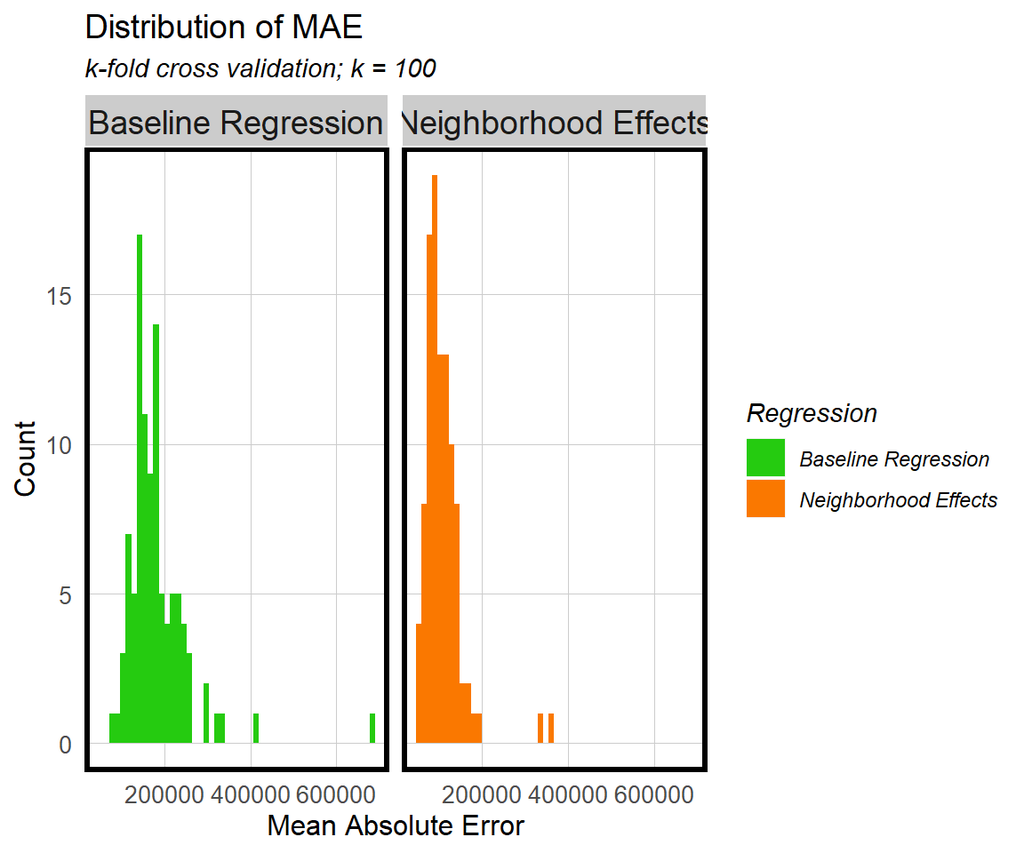